# 131 Project Final Draft

Anna Bauer, Grant Cai, Alexis Navarra

3/1/2022

## Introduction

For this machine learning project, we chose to explore Spotify music and what makes a song popular because we all listen to music frequently and have specific genres that we enjoy. Something we’ve always wondered about is why we enjoy a particular song, and as a consequence, how certain songs become more popular over others. Is it the artist singing the song, the fact that we’ve heard it on the radio, the beats per minute, or is it whether the lyrics are explicit? To come up with a solution to these questions, our goal is to get to know our data thoroughly, create visualizations of the attributes of our question, run regression models to find which attributes are most relevant, select and fine tune a model, and convey our results in an easily understandable report. This brings us to our research question: can we predict a song’s popularity based on its attributes?

## Loading Data and Packages

The first step of our machine learning project is simple: find a data set. Only it was not quite as simple as we anticipated. We went through a multitude of datasets to find a dataset that did not face us with problems such as too many missing values, too many observations, too little observations, and more. This process took much longer than we expected, as it comprised of downloading multiple files and attempting to upload them into git, only to discover that they didn’t satisfy all of our data needs to explore our research question.

Finally, we landed on a dataset from a Kaggle project called “Music Recommendation System using Spotify Dataset”, for which a codebook is attached in our zip files. Below, we provide the list of general packages we used for this project (model-specific packages will be included in the model-building section), along with a preview of our dataset.

```r
# list all packages here
library(tidyverse)
library(knitr)
library(lubridate)
library(httpuv)
library(cluster)
library(factoextra)
library(data.table)
```

```r
library(dplyr)
library(ggplot2)
library(corrplot)
# load music.csv
music <- read.csv("/Users/Grant/DoubleProjectGroup/131 Project/Spotify Dataset/musicdata.csv")

# music.csv preview
head(music)
```

```
##   valence year acousticness             artists danceability duration_ms energy
## 1   0.328 1960        0.547      ['Etta James']        0.274      179693  0.348
## 2   0.402 1960        0.829      ['Etta James']        0.421      196133  0.285
## 3   0.644 1960        0.764 ['Ella Fitzgerald']        0.508      175987  0.287
## 4   0.836 1960        0.733 ['Ella Fitzgerald']        0.579      131733  0.502
## 5   0.965 1960        0.699     ['Neil Sedaka']        0.743      139200  0.799
## 6   0.407 1960        0.878       ['Sam Cooke']        0.553      165560  0.291
##   explicit                     id instrumentalness key liveness loudness mode
## 1        0 4Hhv2vrOTy89HFRcjU3QOx         1.33e-02   5   0.3340   -8.631    1
## 2        0 0zGLlXbHlrAyBN1x6sY0rb         1.55e-06   2   0.2330   -9.430    0
## 3        0 4ukUoXLuFzMixyZyabSGc4         0.00e+00   1   0.1530  -12.472    1
## 4        0 65irrLqfCMRiO3p87P4C0D         0.00e+00   8   0.2810   -7.570    1
## 5        0 2x6pbpjVGjiWCcH89IK8AX         0.00e+00   8   0.0635   -5.466    0
## 6        0 0BFEyqJ9DJXS7gKg0Kj46R         0.00e+00   4   0.1290  -10.426    0
##                        name popularity release_date speechiness   tempo
## 1                   At Last         76         1960      0.0293  87.430
## 2     A Sunday Kind Of Love         70         1960      0.0293  85.861
## 3               Sleigh Ride         69       1/1/60      0.0523 154.759
## 4        Frosty The Snowman         69       1/1/60      0.0513  76.816
## 5 Breaking Up Is Hard to Do         62     12/30/60      0.0375 116.112
## 6               You Send Me         59       1/1/60      0.0301  96.217
```

## Data Pre-processing

In our initial look at this dataset, we wanted to identify any concerns early on so that we could either address them in our data pre-processing or look for a new dataset if the concerns were too large to overcome. The first problem in our data we looked for was missing values. After running a summary of the dataset, we found that there were no NA values, which we took as a good sign. We did notice that some of the ‘release_date’ values only contained the release year and not the exact release data of the song, but we figured this would not be a problem for our exploration. Additionally, we were thrown off by the number of zero values we saw in our initial look at the data, specifically in the columns ‘explicit’ and ‘mode’, but after further examination, we realized that they were coded dummy variables, so this was not a problem for our exploration. We also determined that we did not want to drop either of these variables from our data set, as we felt that if a song is explicit or not could be influential in how popular it becomes, and we felt that if a song was in a minor key or a major key could also be influential in how popular it becomes.

Thus, we begin our data pre-processing by mutating our dummy variables `explicit` and `mode` into as.factor variables. If, for a given song, explicit = 0, we label that as “Clean”, and if explicit = 1, we label that “Explicit”. If, for a given song, mode = 0, we label that as “Minor”, and if mode = 1, we label that as “Major”.

```r
# mutate our dummy variables into as.factor
# music = music %>%
#   mutate(explicit = as.factor(ifelse(explicit == 0, "Clean", "Explicit"))) %>%
#   mutate(mode = as.factor(ifelse(mode == 0, "Minor", "Major")))
```

As our research question requires us to take a regression approach, we did have a concern of our data having too many categorical variables to fit into our regressive model with this data. To address this problem, we thought about what variables would be most important to our data exploration. One of the variables that we thought would be most important to include was ‘artists’, as we know that the artist of a song can have a direct impact on the song’s popularity: a more popular artist is more likely to release a song that has higher popularity, and vice versa. With the `artists` column being string-valued categorical observations, and with there being so many different artists in our data, we wanted to find a way to incorporate this variable into our data as a unique but quantitative variable. We decided that this would be the next step of our data mutation

In order to keep the important variable of `artists` but make it quantitative, we decided to take the average song popularity by each artist in the data, and assign that variable of average artist popularity to each artist as a new variable in the dataset. Thus, our dataset would lose the column ‘artists’ containing each artist’s name, and instead assign the variable `avg_art_pop` as the artist’s average song popularity. This variable mutation process is outlined in the code chunk below.

```r
## manipulation of 'artist' variable

# create a new table that aggregates the variables popularity and artists and finds the mean song popularity for each given artist
artist_pop_table <- aggregate(music$popularity, list(music$artists), FUN = mean)

# merges the table above into our music dataset by artist
full_merge <- merge(x = music, y = artist_pop_table, by.x = c("artists"), by.y = c("Group.1"), all.x = TRUE)

# rename full dataset and x column
full_data <- rename(full_merge, avg_art_pop = x)

# delete previous 'artist' column
delete1 <- c("artists")
full_data <- full_data[!(names(full_data) %in% delete1)]
head(full_data)
```

```
##   valence year acousticness danceability duration_ms energy explicit
## 1   0.460 2012       0.0280        0.730      279080  0.682        1
## 2   0.841 1964       0.0589        0.681      177427  0.499        0
## 3   0.952 1966       0.1460        0.616      133413  0.881        0
## 4   0.827 1966       0.1410        0.659      131480  0.573        0
## 5   0.678 1966       0.5060        0.776      149267  0.764        0
## 6   0.963 1966       0.1050        0.646      170827  0.926        0
##                       id instrumentalness key liveness loudness mode
## 1 55iiBrGOWT5W99VKy4Fk2C         2.87e-06   7   0.1140   -4.517    1
## 2 4v75K5mEyumdXCZU09kwAg         6.39e-06   7   0.0743   -6.894    1
## 3 63Vw8PU3ps8TAxDdHAUTMX         7.52e-01   5   0.0643   -6.357    1
## 4 40NHppXZVM0eYvsVseywWl         9.70e-05   2   0.0779  -10.183    1
## 5 0HmDZd0eP9PVMaZggRp6Em         0.00e+00   0   0.1760   -8.336    1
## 6 23MXQSnv6ZrZUiLy6DdnYl         8.00e-01   0   0.0884   -5.933    1
##                     name popularity release_date speechiness   tempo
## 1               Badlands         46      3/26/12      0.1430 147.988
## 2               96 Tears         42       1/1/64      0.0340 123.458
## 3        I Need Somebody         23         1966      0.0372 134.048
## 4            Ten O'clock         16         1966      0.0336  96.254
## 5 You're Telling Me Lies         15         1966      0.0802  88.574
## 6                Up Side         26         1966      0.0426 125.672
##   avg_art_pop
## 1    46.00000
## 2    25.11111
## 3    25.11111
## 4    25.11111
## 5    25.11111
## 6    25.11111
```

```r
# delete variables that will not be useful in our exploration
delete2 <- c("id", "key", "name", "release_date")
full_data <- full_data[!(names(full_data) %in% delete2)]
```

And finally, after making sure that all of our quantitative variables were numeric (shown in code chunk below), our data was ready for some exploratory data analysis.

```r
# mutating leftover int variables to num type
full_data$popularity <- as.numeric(full_data$popularity)
full_data$year <- as.numeric(full_data$year)
full_data$duration_ms <- as.numeric(full_data$duration_ms)
```

## Exploratory Data Analysis

We first set out to explore the relationship between the various predictors and the response variable, popularity. We first subset the data to a more manageable size so that we could discern something from exploratory data analysis:

```r
set.seed((123))
# sample data to use for exploratory graphics
sample <- full_data[sample(nrow(full_data), 200), ]
```

After defining our various plots, we accumulate them into a panel for better visibility:

```r
# library(patchwork)
# valence + year + acousticness
# danceability + duration + energy
# explicit + instrumentalness +  key
# liveness +  loudness + mode
# speechiness +  tempo + avg_art_pop
```

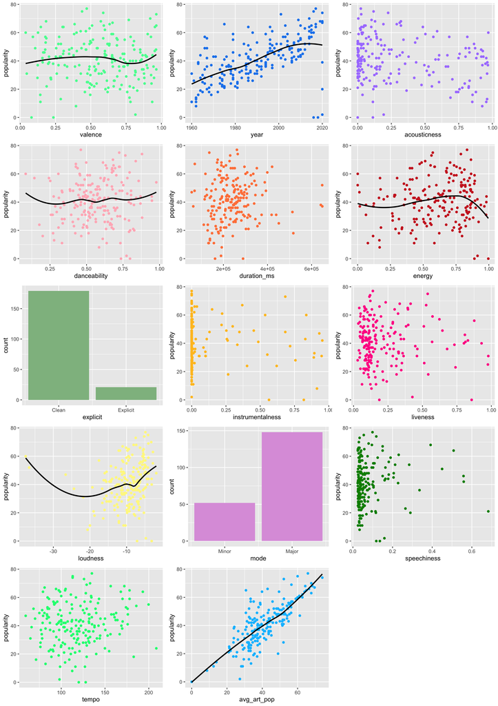

```r
library(ggpubr)
figure <- ggarrange(valence, year, acousticness, danceability, duration, energy, explicit, instrumentalness, liveness, loudness, mode, speechiness, tempo, avg_art_pop, ncol = 3, nrow = 5)
figure
```

Looking specifically at the variables that have the strongest relationships with popularity, the two predictors `year` and `avg_art_pop` appear to have the strongest positive correlation with popularity. This makes intuitive sense.

There are several factors that could explain why year has a positive, near linear, relationship with popularity: for one, the population has increased from the 1960s until present day. With more people comes a more active listening base for artists to reach. In addition, the methods by which we obtain music have changed over the decades, starting off with things like records and record players, CDs, iTunes, and now with music streaming through platforms like Spotify.

It makes intuitive sense why an artist’s average popularity would be positively correlated with popularity. An artist with high brand value or recognition, such as Kendrick Lamar, Ariana Grande, or Justin Bieber are more likely to have new releases listened to by significantly more people as opposed to a more obscure or lesser known artist such as Gus Dapperton or Peach Pit.

This relationship is clearly shown through a correlation matrix and subsequent heatmap:

```r
# making some of the int variables into numeric
full_data$popularity <- as.numeric(full_data$popularity)
full_data$year <- as.numeric(full_data$year)
full_data$duration_ms <- as.numeric(full_data$duration_ms)

# mutating dummy variables
full_data2 = full_data %>%
  mutate(explicit = as.factor(ifelse(explicit == 0, "Clean", "Explicit"))) %>%
  mutate(mode = as.factor(ifelse(mode == 0, "Minor", "Major")))

# modifying our full data to leave out the variables we don't want
delete <- c("artists", "id", "key", "name", "release_date")
full_data <- full_data[!(names(full_data) %in% delete)]
```

```r
# correlation matrix and heatmap
library(corrplot)
corr_mat <- cor(full_data)
corr_mat[, 12]
```

```
##          valence             year     acousticness     danceability
##      -0.05766409       0.68198486      -0.24959846       0.18750900
##      duration_ms           energy         explicit instrumentalness
##      -0.02197240       0.19717541       0.26782335      -0.14840380
##         liveness         loudness             mode       popularity
##      -0.07600035       0.31230798      -0.06658299       1.00000000
##      speechiness            tempo      avg_art_pop
##       0.10043080       0.03306722       0.81967675
```

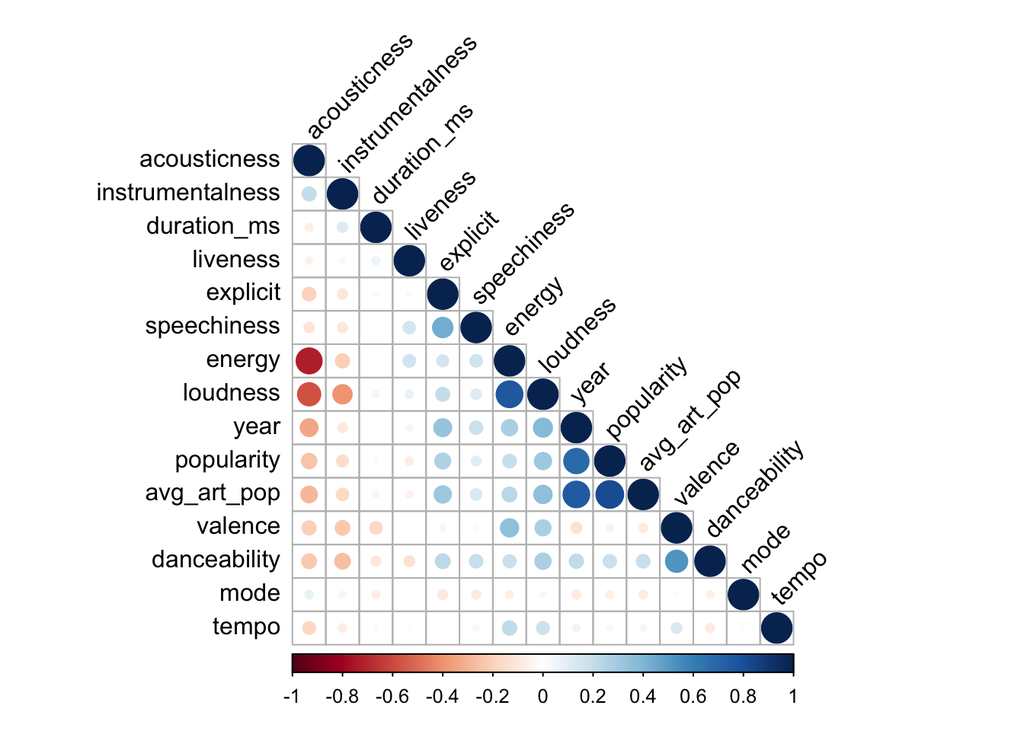

```r
corrplot(corr_mat, type = "lower", order = "hclust", tl.col = "black", tl.srt = 45)
```

The heatmap reinforces the notion that the two predictors with the strongest positive association with popularity are `year` and `avg_art_pop`. We thus have reason to believe that they will be influential and important to include in our model building.

Finally, an analysis of the distribution of the response `popularity` allows us to see that it is pretty normally-distributed.

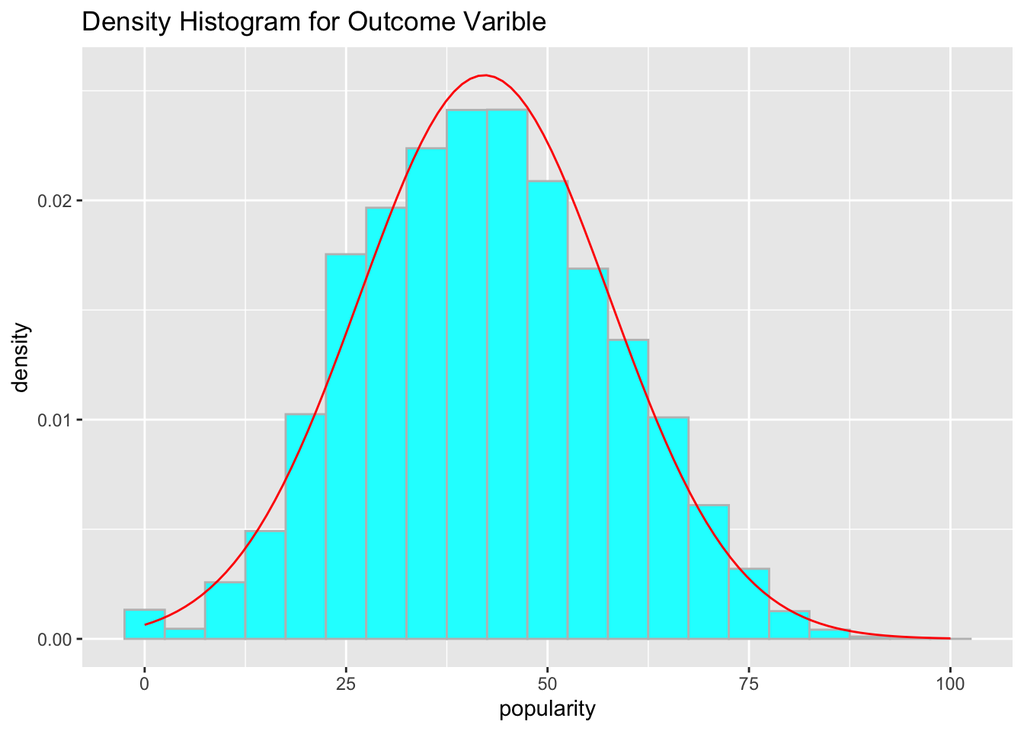

```r
# adding a density histogram for our outcome variable popularity
hist <- ggplot(full_data) +
  ggtitle("Density Histogram for Outcome Varible") + # include title
  geom_histogram(aes(popularity, y = after_stat(density)), binwidth = 5, fill = "cyan", color = "grey")  # add histogram w density
x <- seq(0, 100, length.out = 100)
df <- with(full_data, data.frame(x=x, y = dnorm(x, mean(popularity), sd(popularity))))
hist + geom_line(data = df, aes(x = x, y = y), color = "red")
```